# How does religion and science related in the field of Philosophy?

Wenhui Fang

02/02/2022

# Introduction

The term “philosophy” seems a word that are used in many conversations. When our parents taught us their life experience, they called their words, “philosophy”. When English teacher explained a book, they used the word, “philosophy”. What does “philosophy” really mean? Different people have different interpretation. The data set we have consists over 360,000 sentences that 36 philosophers said. These philosophers are from different ages, varied from 350 BC to 2000 AD. With the large data set, we are able to study the history and the contents of philosophy.

Socrates once said, “Having the fewest wants, I am nearest to the gods”. Religion seems to be an important topic through the history of philosophy. With the large dataset, we can explore the development of philosophy entangling with religion. Moreover, science is an important topic in the field of philosophy as well and people sometimes believes that religion and science are opposites. Therefore, with the large dataset, we will explore the relationship between philosophy, religion and science by trying to answering the following questions.

1. Does religion and science are opposites in the field of philosophy?
2. Are science and religion often brought up together?
3. How does the sentiment toward science and religion for each school?
4. How does the relationship between philosophy and science, religion change over time?
5. How does the attitude towards science and religion change over the year?

Therefore, to study the contents of philosophy, the topic and the direction of data analysis will be the relationship between science, religion and philosophy.

# About the Data

## Data overview

```r
library(tidyverse)
```

```r
library(tibble)
library(dplyr)
library(stringr)
library(writexl)
library(tidytext)
library(syuzhet)
library(gplots)
data <- read.csv('philosophy_data.csv')
names(data)
```

```
##  [1] "title"                     "author"
##  [3] "school"                    "sentence_spacy"
##  [5] "sentence_str"              "original_publication_date"
##  [7] "corpus_edition_date"       "sentence_length"
##  [9] "sentence_lowered"          "tokenized_txt"
## [11] "lemmatized_str"
```

```r
dim(data)
```

```
## [1] 360808     11
```

```r
author <- data%>%select(author)%>%unique
school <- data%>%select(school)%>%unique
author_school <- data%>%select(author, school)%>%unique
```

From the data, we can see that the data not only includes the sentences that 36 philosophers said, it also provides the book containing sentences, published year, authors, and schools. Since the year of each sentences were not provided, we will treat the publication date of books as the year of each sentences. There are 13 schools and 36 authors and over 360,000 sentences.

## Is data balanced over authors, schools and years?

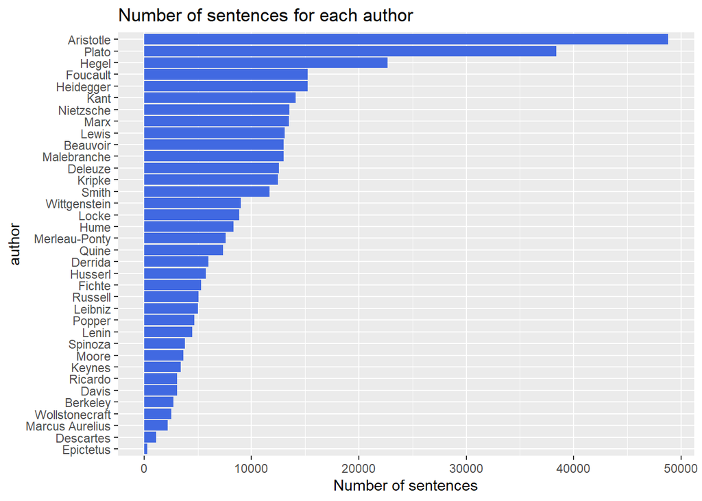

```r
data <- data%>%select(-sentence_lowered,-sentence_spacy,-corpus_edition_date)%>%rename(year = original_publication_date)
data%>%select(author)%>%group_by(author)%>%summarize(count = n())%>%
  mutate(author = fct_reorder(author, count))%>%
  ggplot(aes(x = author, y = count)) +
  coord_flip() + geom_col(fill = "royalblue") +
  labs(title = "Number of sentences for each author",
       y = "Number of sentences")
```

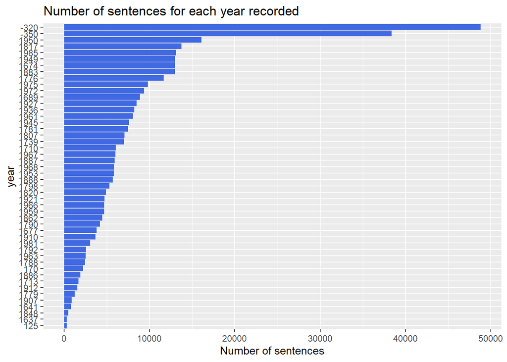

```r
data%>%select(year)%>%group_by(year)%>%summarize(count = n())%>%
  mutate(year = factor(year), year = fct_reorder(year, count))%>%
  ggplot(aes(x = year, y = count)) +
  coord_flip() + geom_col(fill = "royalblue") +
  labs(title = "Number of sentences for each year recorded",
       y = "Number of sentences")
```

From the graph, we can see that the data is severely unbalanced for authors and years. Therefore, to avoid potential bias, we will use percentage for every data analysis followed. Also, there is a huge gap between year 125 to 1600, in the analysis related to time, we will discard the sentences before the year 1600.

## Determine if the topic can be analyzed by the data

### Religion

To pick out the sentence related to religion, we use the philosophy data project website. It provides ten words that most relevant words to the key word that are used in the data. The key words we are using are, “religion”,“god”,“Zeus”, and their most relevant words are used to search religious sentences.

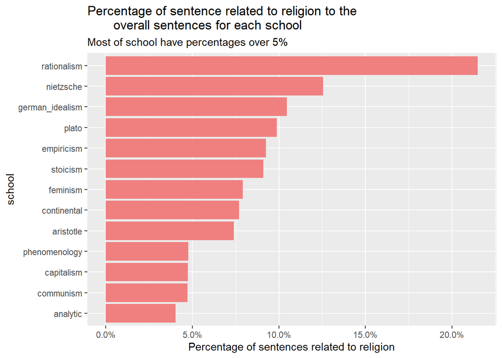

```r
# Religion sentence
rel_sentence <- data%>%
  filter(str_detect(lemmatized_str,"(G|g)od|(D|d)eity|(J|j)esus|(W|w)isdom|
                    (G|g)race|(D|d)ivin|(S|s)in|(C|c)reator|
                    (E|e)ternal|(S|s)upreme|(T|t)heology|(C|c)hrist|(A|a)pollo|
                    (A|a)lcibiades|(M|m)inos|(A|a)chilles|(P|p)ericles|
                    (A|a)phrodite|(F|f)aith|(E)eternal|(C|c)reator|
                    (P|p)rovidence"))
rel_sentence_school_count<-rel_sentence%>%group_by(school)%>%
  summarise(rel_sentence_count = n())%>%
  left_join(data%>%group_by(school)%>%summarize(sentence_count=n()),by = "school")%>%
  mutate(rel_sentence_perc = rel_sentence_count/sentence_count)%>%
  mutate(school = fct_reorder(school, rel_sentence_perc))

rel_sentence_school_count%>%
  ggplot(aes(x = reorder(school,rel_sentence_perc), y = rel_sentence_perc)) + geom_col(fill = "lightcoral") +
  coord_flip() +
  labs(title = "Percentage of sentence related to religion to the
       overall sentences for each school",
       subtitle = "Most of school have percentages over 5%",
       y = "Percentage of sentences related to religion", x = "school")+
    scale_y_continuous(labels = scales::percent)
```

```r
cat('Overall percentage of sentences that are related to religion is,',sum(rel_sentence_school_count$rel_sentence_count)/sum(rel_sentence_school_count$sentence_count)*100,"%")
```

```
## Overall percentage of sentences that are related to religion is, 8.285847 %
```

Overall, there are 8% of sentences are related to religion, which is about 30,000 sentences left. For a big data set containing over 360,000 sentences, we can see that philosophy concerned about the religion, and we can use the data to analyze the topic. From the graph, we can see that over 5 to 8 percent of sentences are related to religion. Rationalism is the most related school to religion and over 20 percent of sentences from them concerned about God. The least related school is analytic, but it still has over 4% of sentences. In this dataset with 36 philosophers, we can conclude that religion is an important topic for them.

### Science

For science, the key words we are using are “Science”, “Mathematics”, and “Physicis”.

```r
sci_sentence <- data%>%
  filter(str_detect(lemmatized_str,"(S|s)cience|
                    (M|m)ath|(P|p)sycolog|(P|p)hilosop|
                    (L|l)ogic|(P|p)hysic|(T|t)heolo|(M|m)edic|
                    (S|s)cientific|(G|g)eomet|(A|a)stro"))
sci_sentence_school_count<-sci_sentence%>%group_by(school)%>%
  summarise(sci_sentence_count = n())%>%
  left_join(data%>%group_by(school)%>%summarize(sentence_count=n()))%>%
  mutate(sci_sentence_perc = sci_sentence_count/sentence_count)
```

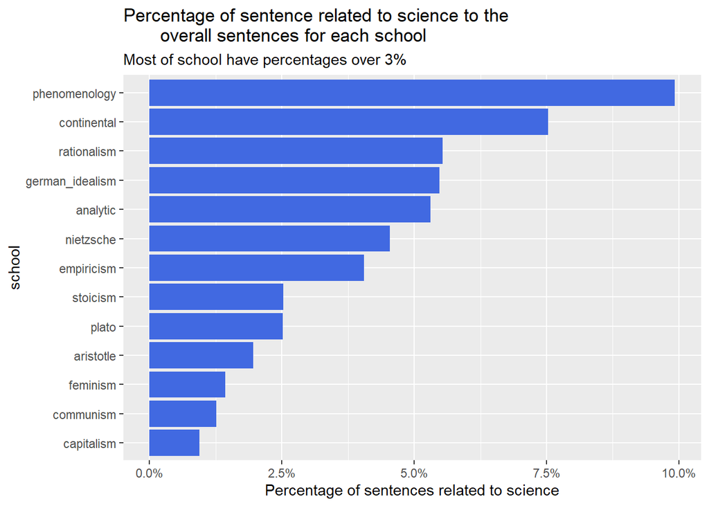

```r
sci_sentence_school_count%>%
  mutate(school = fct_reorder(school, sci_sentence_perc))%>%
  ggplot(aes(x = school, y = sci_sentence_perc)) + geom_col(fill = "royalblue") +
  coord_flip() +
  labs(title = "Percentage of sentence related to science to the
       overall sentences for each school",
       subtitle = "Most of school have percentages over 3%",
       y = "Percentage of sentences related to science") +
    scale_y_continuous(labels = scales::percent)
```

```r
cat('Overall percentage of sentences that are related to science is,',sum(sci_sentence_school_count$sci_sentence_count)/sum(sci_sentence_school_count$sentence_count)*100,"%")
```

```
## Overall percentage of sentences that are related to science is, 4.427285 %
```

Overall, the percentage of sentences that are related to science is 4%. For each school, most of them are over 3 to 4 percentages. The school that are most concerned about science is phenomenology with almost 10% of sentences related to science. School that least concerned about science is capitalism which has about 1%.

Therefore, after data mining, we can see that religion and science play significant roles in the field of philosophy.